# Forecasting UK Inflation with Prophet

MTH6139 Time Series Coursework 1

Kardelen Karaoglan

Spring term 2026

# 1. Introduction

This project looks at UK inflation using Meta’s Prophet forecasting model in R. The data used is the Consumer Prices Index (CPI) annual rate for all items, taken from the Office for National Statistics (ONS).

Inflation is a particularly interesting time series because it reflects changes in the wider economy. It can show long periods of relative stability, but also sudden shifts during major economic events. For example, the COVID-19 pandemic led to sharp disruptions in prices and supply chains, followed by a period of unusually high inflation. This makes inflation a useful case study for forecasting, and for assessing how well Prophet can capture patterns in data that are not perfectly smooth.

The report begins by introducing the dataset and exploring its main features using graphs. It then explains how the data is prepared for Prophet, fits a basic model, and compares it with a few alternative versions. Finally, the results are discussed, along with the limitations of the model and the main conclusions.

# 2. The dataset

The data used in this project is monthly UK inflation data from the Office for National Statistics (ONS). More specifically, the series chosen is the Consumer Prices Index (CPI) annual rate for all items.

This dataset is appropriate because it is recorded regularly over time and is important in practice. Inflation is influenced by changes in the economy, government policies and unexpected events, which means it does not follow a perfectly smooth pattern. This makes it a more realistic and slightly more challenging example for forecasting with Prophet.

The data also requires some preparation before it can be used. The original file includes extra information and a mix of annual and monthly observations, so the monthly data needs to be extracted and converted into the correct format for Prophet.

# 3. Exploratory analysis

## 3.1 Time series plot

A first time series plot gives an overview of how UK inflation behaves over the sample period. It helps to highlight general trends, as well as any unusual movements, before fitting a forecasting model.

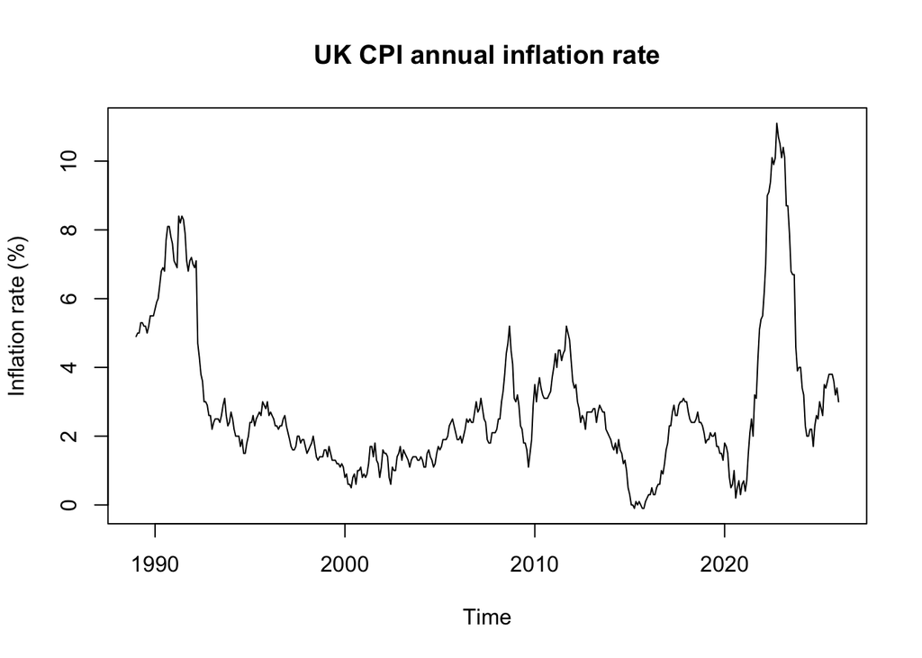

The plot shows that inflation doesn’t stay at a constant level, but instead moves around consistently over time. For example, it is fairly high in the early 1990s (around 7–8%), before dropping and staying lower and more stable through the late 1990s and early 2000s (around 1–3%). There are also a few more volatile periods, such as around 2008 and 2011, where inflation rises again for a short time.

One of the most noticeable features is the sharp increase in the early 2020s, where inflation goes above 10%, followed by a quick fall. Overall, this suggests that inflation is influenced by changing economic conditions and occasional shocks, which may make it harder for a smooth forecasting model to fully capture its behaviour.

## 3.2 Moving average

To make the overall direction of the series easier to see, the data is smoothed using a 12-month moving average.This reduces short-term fluctuations and highlights the main pattern in the data.

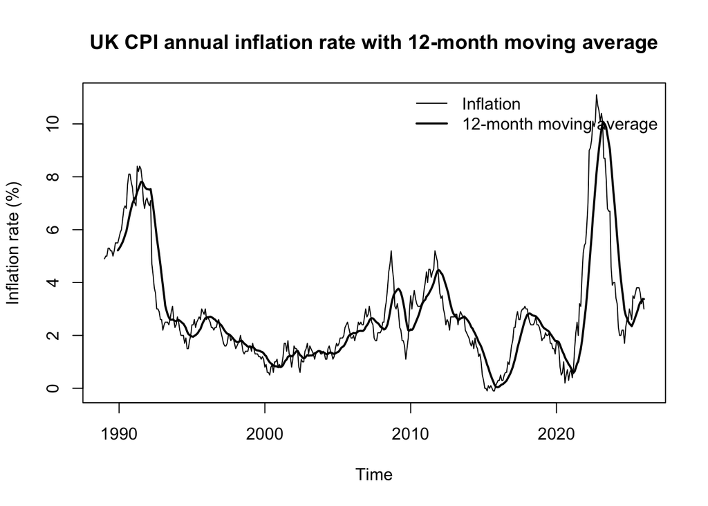

This suggests that inflation does not follow a single stable pattern, but instead changes over time in response to different economic conditions.

## 3.3 Distribution of inflation

A histogram helps to show how inflation values are spread across the sample. It gives an idea of where most values lie and whether there are any unusually high or low observations.

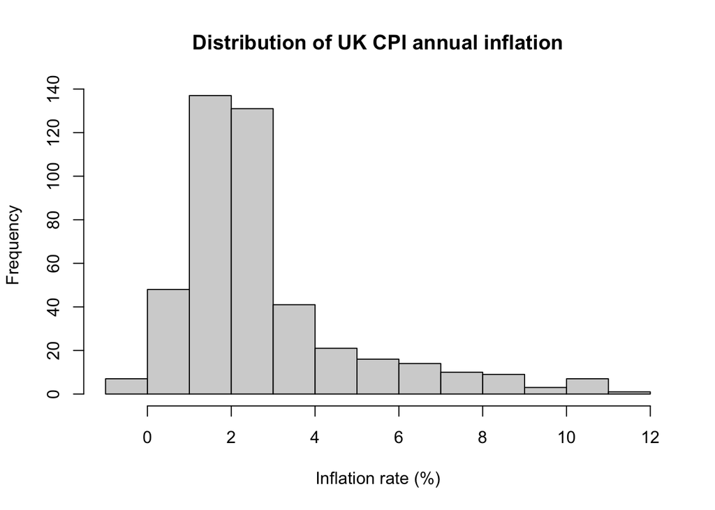

The histogram shows that inflation is not concentrated around a single narrow level. Most values fall within a low to moderate range, but there are also some much higher observations. This suggests that inflation occasionally experiences more unusual periods, which matches the sharp movements seen in the time series plot.

## 3.4 Inflation by calendar month

A boxplot by calendar month can be used to check whether inflation behaves differently at different times of the year. If there is a clear seasonal pattern, it should show up as noticeable differences between the months.

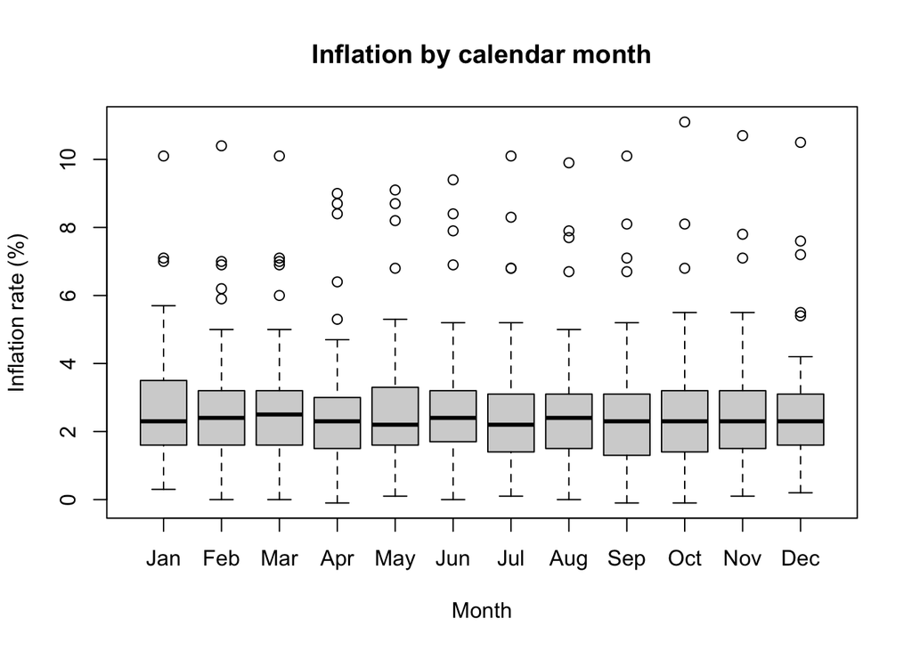

The monthly boxplots do not show a strong or consistent seasonal pattern. Any differences between months are fairly small compared to the larger changes in inflation over time. This suggests that seasonal effects are relatively weak, which is useful to keep in mind when interpreting Prophet’s seasonal components later in the report.

## 3.5 Summary statistics

Summary statistics gives a simple overview of the main features of the data, such as its typical value and how much it varies. They help to support what we have already seen in the plots.

```
     Statistic    Value
1      Minimum -0.10000
2 1st quartile  1.50000
3       Median  2.30000
4         Mean  2.83618
5 3rd quartile  3.20000
6      Maximum 11.10000
```

The summary statistics show that inflation varies quite a lot. It ranges from slightly below 0% to over 11%, although most values tend to sit between about 1.5% and 3%. This fits with what we saw in the plots, where inflation is fairly stable at times but also has some bigger spikes, so any forecasts should be interpreted with a bit of caution.

# 4. Preparing the data for Prophet

Prophet requires the data to be in a specific format, with two columns: `ds`, for the dates, and `y`, for the observed values.

The original ONS file is not in this format, as it includes extra information and a mix of annual and monthly observations. To prepare the data for modelling, the monthly values are extracted and converted into a clean data frame.

```
          ds   y
1 1989-01-01 4.9
2 1989-02-01 5.0
3 1989-03-01 5.0
4 1989-04-01 5.3
5 1989-05-01 5.3
6 1989-06-01 5.2
```

```
            ds   y
440 2025-08-01 3.8
441 2025-09-01 3.8
442 2025-10-01 3.6
443 2025-11-01 3.2
444 2025-12-01 3.4
445 2026-01-01 3.0
```

The monthly data is then organised into the required ds and y format, where ds contains the dates and y contains the inflation values. The final dataset runs from January 1989 to January 2026.

# 5. Baseline Prophet model

The first model fitted is a baseline Prophet model using the full inflation dataset. This provides a reference point for later comparisons and shows how well Prophet captures the overall behaviour of the series when all the data is used.

The model produces forecasts for the next 24 months, covering two years beyond the available data.

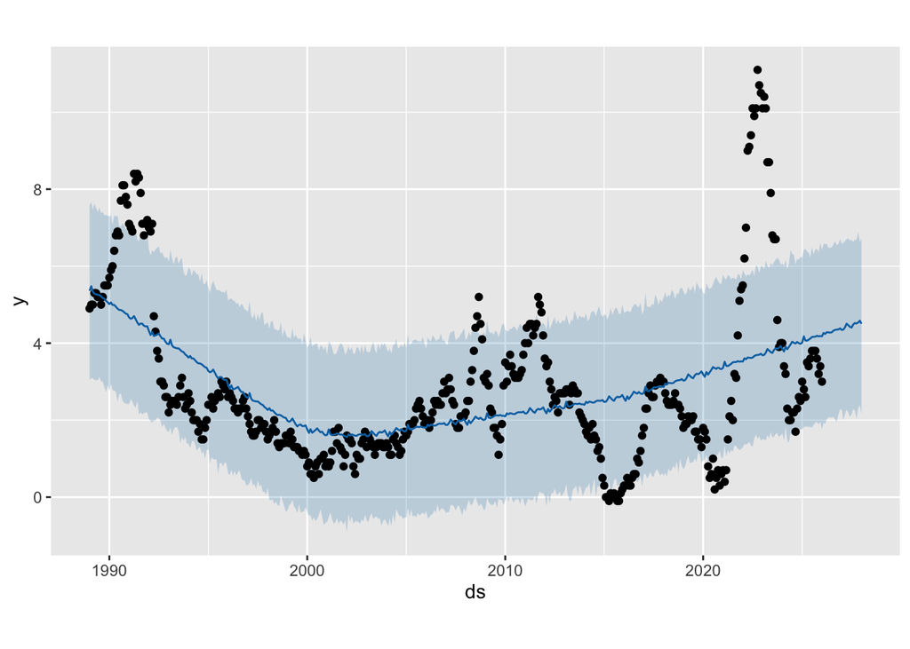

The forecast plot shows that the baseline Prophet model captures the general movement of inflation over time, but it does not fully reflect some of the sharper changes in the data. In particular, the sharp increase in inflation in the early 2020s is much steeper than the fitted trend. This suggests that while Prophet is useful for describing the overall direction of inflation, it may struggle to capture sudden changes or more extreme movements.

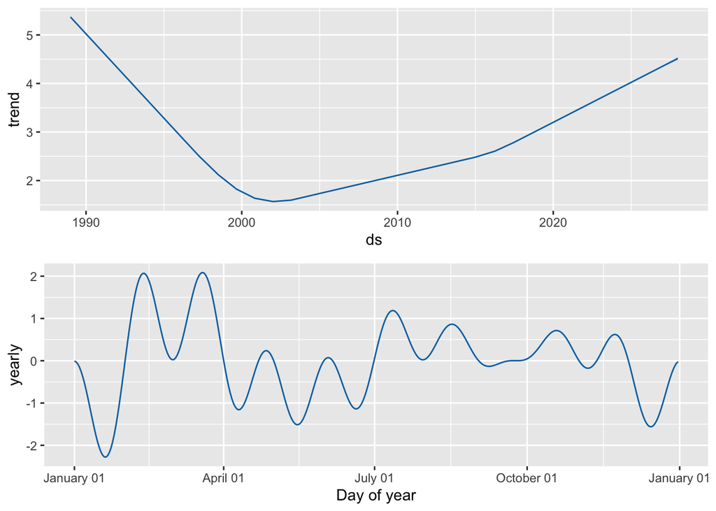

The components plot separates the estimated trend from the seasonal pattern identified by the model. In this case, the trend component is more informative than the seasonal component, as earlier analysis suggested that any seasonal effects in inflation are relatively weak compared to the larger changes over time.

```
            ds     yhat yhat_lower yhat_upper
458 2027-02-01 4.353949   1.994832   6.609787
459 2027-03-01 4.409559   2.153200   6.652816
460 2027-04-01 4.505957   2.268434   6.700007
461 2027-05-01 4.467341   2.206164   6.724158
462 2027-06-01 4.425069   2.082084   6.662857
463 2027-07-01 4.405053   2.145360   6.691180
464 2027-08-01 4.482817   2.289741   6.625329
465 2027-09-01 4.522797   2.247616   6.688614
466 2027-10-01 4.511232   2.036164   6.685792
467 2027-11-01 4.537777   2.307592   6.896667
468 2027-12-01 4.582946   2.392621   6.621207
469 2028-01-01 4.504422   2.153231   6.724065
```

The table above shows the final part of the forecast along with the lower and upper uncertainty bounds. These intervals highlight that there is still uncertainty in future inflation, even though the model provides a smooth central prediction.

# 6. Alternative Prophet models

To see how much the results depend on the modelling choices, the baseline model is compared with a few alternative versions. These look at what happens when we change the sample period and how seasonality is handled.

## 6.1 Prophet on post-2000 data

One possible issue with the baseline model is that very old data might influence the trend too much. To look into this, a second model is fitted using only data from January 2000 onwards. This means the model focuses more on recent inflation behaviour.

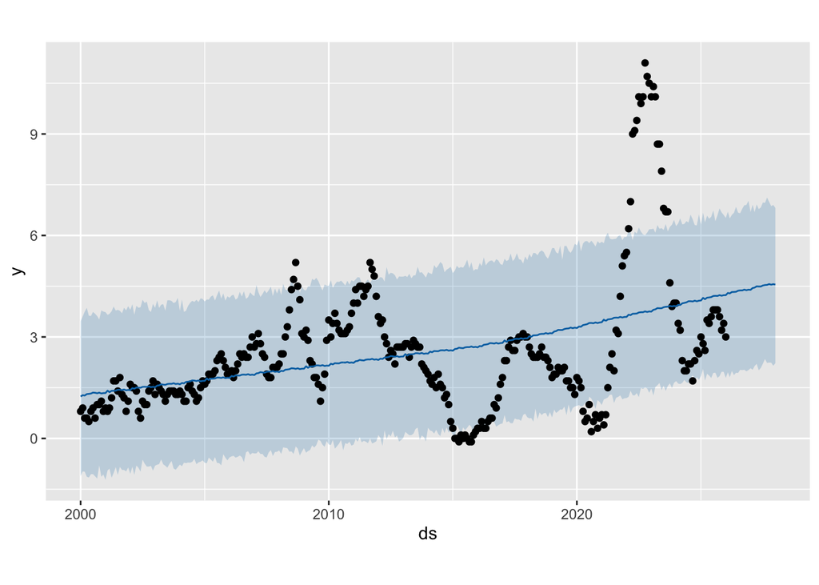

Using only post-2000 data gives more weight to recent movements in inflation. This can be helpful, since the way inflation behaves may have changed over time. As a result, using the full dataset might smooth over patterns that are more relevant today.

## 6.2 Prophet without yearly seasonality

From the earlier analysis, any seasonal pattern in inflation appeared to be quite weak compared to the overall changes in the series. To check this, another model is fitted with yearly seasonality removed.

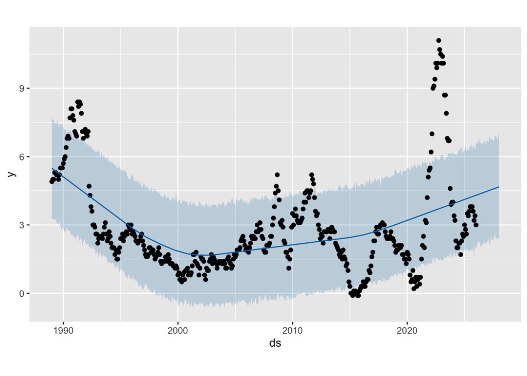

This version focuses more on the overall trend. If the results are similar to the baseline model, this suggests that seasonality is not a key feature of this inflation series.

# 7. Forecast comparison

The three Prophet models can now be compared to see how much the forecasts change depending on the sample period and how seasonality is handled. This is useful because, for a series like inflation, different modelling choices can lead to noticeably different results.

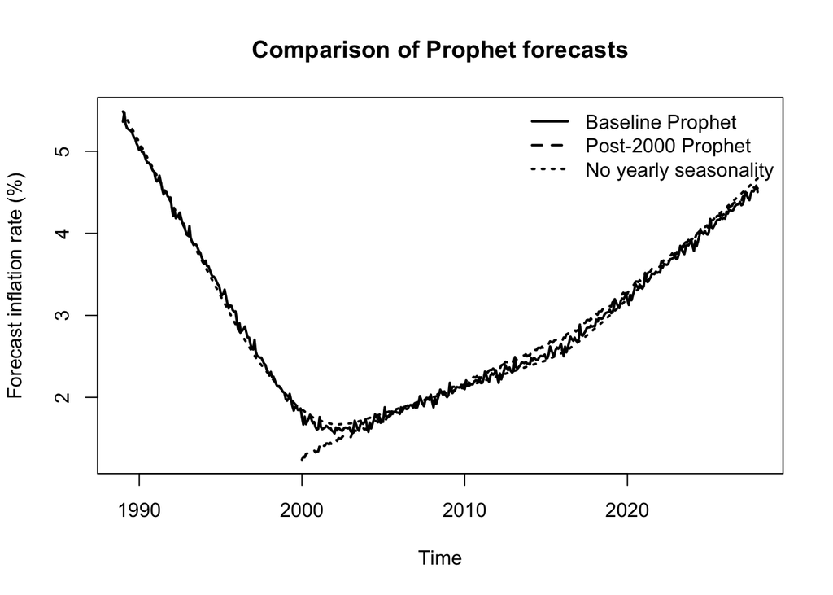

The comparison shows that all three forecasts follow a similar overall pattern, but there are some differences. The model using post-2000 data is more influenced by recent inflation movements, while removing yearly seasonality only leads to small changes in the forecast.

# 8. Discussion

The results show that Prophet is able to capture the overall movement in inflation, particularly the gradual changes in level over time. Across all models, the general pattern is similar, suggesting that the main trend is fairly stable regardless of the modelling choices.

However, the forecasts are less effective at capturing sudden changes in inflation. In particular, the sharp increase in the early 2020s is not fully reflected by the model, which instead produces a smoother trend. This highlights a limitation of Prophet when applied to economic time series that are influenced by shocks or structural changes.

Overall, the analysis suggests that while Prophet is useful for understanding the general direction of inflation, its forecasts should be interpreted with caution, especially during periods of rapid change.

# 9. Conclusion

This project analysed UK inflation using Prophet and explored how different modelling choices affect the forecasts. The baseline model provided a useful starting point, capturing the overall pattern in the data but smoothing over more extreme movements.

In conclusion, Prophet is a useful and flexible tool for forecasting inflation, especially for identifying broad trends. However, it has limitations when dealing with sudden changes, so its results should be used alongside economic understanding and interpreted carefully.

# Data source and software (References)

The inflation series used in this project was obtained from the [Office for National Statistics (ONS)](https://www.ons.gov.uk/) time series database.

Forecasts were produced in R using [Meta’s Prophet](https://facebook.github.io/prophet/).